© Bản quyền thuộc về Quantopian Inc.  
© Bản quyền sửa đổi thuộc về AI Cafe¹  
Giấy phép [Creative Commons Attribution 4.0](https://creativecommons.org/licenses/by/4.0/legalcode).  
[Khuyến cáo](https://aicafe.one/khuyen-cao/)

# Mô hình Tự hồi quy (AR)

bởi Maxwell Margenot, Delaney Mackenzie và Lee Tobey (founder of Hedgewise)

Edited by AI Cafe¹

## Mô hình AR

Mô hình tự hồi quy, hay AR$(p)$, được tạo ra bằng cách hồi quy một chuỗi thời gian trên các giá trị trong quá khứ của nó, tức là các độ trễ của nó. Dạng đơn giản nhất của một mô hình tự hồi quy là mô hình AR$(1)$, có nghĩa là chỉ sử dụng một hạng mục độ trễ. Một mô hình tự tương quan bậc nhất như vậy cho một chuỗi thời gian $x_t$ là:

$$ x_t = b_0 + b_1 x_{t - 1} + \epsilon_t $$

Trong đó $x_{t - 1}$ đại diện cho giá trị của chuỗi thời gian tại thời điểm $(t - 1)$ và $\epsilon_t$ là hạng mục sai số. Chúng ta có thể mở rộng điều này thành mô hình AR$(p)$, được ký hiệu:

$$ x_t = b_0 + b_1 x_{t-1} + b_2 x_{t - 2} \ldots + b_p x_{t - p} + \epsilon_t $$

Để một mô hình AR hoạt động đúng, chúng ta phải yêu cầu rằng chuỗi thời gian là ổn định về hiệp phương sai. Điều này có nghĩa là nó tuân theo ba điều kiện sau:

1. Giá trị kỳ vọng của chuỗi thời gian là không đổi và hữu hạn tại mọi thời điểm, tức là $E[y_t] = \mu$ và $\mu < \infty$ cho tất cả các giá trị của $t$.
2. Phương sai của chuỗi thời gian là không đổi và hữu hạn cho tất cả các khoảng thời gian.
3. Hiệp phương sai của chuỗi thời gian với chính nó trong một số lượng cố định các khoảng thời gian trong tương lai hoặc quá khứ là không đổi và hữu hạn cho tất cả các khoảng thời gian, tức là

$$ COV(y_t, y_{t - s}) = \lambda, \ |\lambda| < \infty, \text{ $\lambda$ không đổi}, \ t = 1, 2, \ \ldots, T; \ s = 0, \pm 1, \pm 2, \ldots, \pm T $$

Lưu ý rằng biểu diễn toán học này bao gồm điều kiện 2.

Nếu các điều kiện này không được thỏa mãn, kết quả ước lượng của chúng ta sẽ không có ý nghĩa thực tế. Các ước lượng cho các tham số sẽ bị thiên lệch, làm cho bất kỳ thử nghiệm nào mà chúng ta cố gắng thực hiện bằng cách sử dụng mô hình trở nên không hợp lệ. Thật không may, việc tìm một chuỗi thời gian ổn định về hiệp phương sai trong thực tế thị trường tài chính có thể là một thách thức. Ví dụ, khi chúng ta xem xét giá cổ phiếu của FPT, chúng ta có thể thấy rõ một xu hướng tăng. Giá trị trung bình đang tăng theo thời gian. Tuy nhiên, có những cách để làm cho một chuỗi thời gian không ổn định trở nên ổn định. Khi chúng ta đã thực hiện biến đổi này, chúng ta có thể xây dựng các mô hình tự hồi quy dưới các giả định ở trên.

## Mô phỏng Dữ liệu

Ở đây, chúng ta sẽ lấy mẫu dữ liệu từ một quá trình AR$(3)$ được mô phỏng.

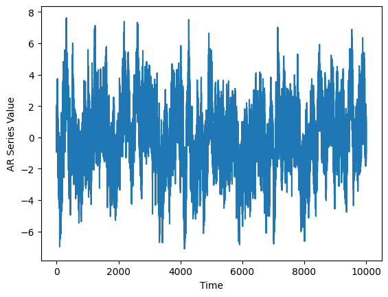

```python
import numpy as np
from scipy import stats
from statsmodels.tsa.ar_model import AutoReg
import matplotlib.pyplot as plt

# ensures experiment runs the same every time
np.random.seed(100)

# This function simluates an AR process, generating a new value based on historial values,
# autoregressive coefficients b1 ... bk, and some randomness.
def AR(b, X, mu, sigma):
    l = min(len(b)-1, len(X))
    b0 = b[0]

    return b0 + np.dot(b[1:l+1], X[-l:]) + np.random.normal(mu, sigma)

b = np.array([0, 0.8, 0.1, 0.05])
X = np.array([1])

mu = 0
sigma = 1

for i in range(10000):
    X = np.append(X, AR(b, X, mu, sigma))

plt.plot(X)
plt.xlabel('Time')
plt.ylabel('AR Series Value');
```

Trong trường hợp này, tuy nhiên, chúng ta đã xây dựng mô hình để trở nên ổn định, vì vậy không cần phải lo lắng về việc kiểm tra tính ổn định ngay bây giờ.

## Rủi ro Đuôi (Tail Risk)

Các quá trình tự hồi quy có xu hướng có nhiều giá trị cực đoan hơn so với dữ liệu được lấy từ một phân phối như phân phối chuẩn chẳng hạn. Điều này là do giá trị tại mỗi điểm thời gian bị ảnh hưởng bởi các giá trị gần đây. Nếu chuỗi ngẫu nhiên này tăng lên, nó có khả năng sẽ duy trì ở mức cao hơn so với một chuỗi không phải tự hồi quy. Điều này được gọi là 'tính dày ở đuôi' (fat-tailedness) vì các giá trị cực đoan trên hàm mật độ xác suất (pdf) sẽ dày hơn so với trong một phân phối chuẩn.

Nhiều cuộc thảo luận về rủi ro đuôi trong tài chính xuất phát từ thực tế rằng các sự kiện ở đuôi thực sự xảy ra và khó mô hình hóa do tần suất xảy ra của chúng thấp. Nếu chúng ta có lý do để nghi ngờ rằng một quá trình là tự hồi quy, chúng ta nên mong đợi rủi ro từ các sự kiện cực đoan và điều chỉnh cho phù hợp.

Mô hình AR chỉ là một trong những nguồn gốc của rủi ro đuôi, vì vậy đừng cho rằng vì một chuỗi không phải là AR, nó không có rủi ro đuôi.

Chúng ta sẽ kiểm tra hành vi đó ngay bây giờ.

```python
def compare_tails_to_normal(X):
    # Define matrix to store comparisons
    A = np.zeros((2,4))
    for k in range(4):
        #stores tail probabilities of the sample series vs a normal series
        A[0, k] = len(X[X > (k + 1)]) / float(len(X)) # Estimate tails of X
        A[1, k] = 1 - stats.norm.cdf(k + 1) # Compare to Gaussian distribution
    print('Frequency of std events in X \n1: %s\t2: %s\t3: %s\t4: %s' % tuple(A[0]))
    print('Frequency of std events in a normal process \n1: %s\t2: %s\t3: %s\t4: %s' % tuple(A[1]))
    return A

compare_tails_to_normal(X);
```

```
Frequency of std events in X
1: 0.32756724327567244	2: 0.18548145185481452	3: 0.09099090090990901	4: 0.0357964203579642
Frequency of std events in a normal process
1: 0.15865525393145707	2: 0.02275013194817921	3: 0.0013498980316301035	4: 3.167124183311998e-05
```

## Các Ước lượng Phương sai sẽ Sai

Vì một quá trình AR có phân phối nặng ở đuôi và không chuẩn, các ước lượng phương sai trên các quá trình AR sẽ bị sai. Điều này là nguy hiểm vì phương sai được sử dụng để tính toán nhiều đại lượng trong thống kê, quan trọng nhất là các khoảng tin cậy và p-value. Vì độ rộng của khoảng tin cậy thường dựa trên một ước lượng phương sai, chúng ta không thể tin tưởng vào các p-value xuất phát từ các quá trình AR. Để biết thêm thông tin về p-value, vui lòng xem bài giảng về Kiểm định Giả thuyết.

Chúng ta sẽ kiểm tra điều này ở đây. Đầu tiên, chúng ta sẽ định nghĩa một số hàm trợ giúp để tính toán một khoảng tin cậy 95% ngây thơ cho giá trị trung bình thực sự trên một chuỗi đầu vào nào đó.

```python
def compute_unadjusted_interval(X):
    T = len(X)
    # Compute mu and sigma MLE
    mu = np.mean(X)
    sigma = np.std(X)
    # Compute the bounds using standard error
    lower = mu - 1.96 * (sigma/np.sqrt(T))
    upper = mu + 1.96 * (sigma/np.sqrt(T))
    return lower, upper

# We'll make a function that returns true when the computed bounds contain 0
def check_unadjusted_coverage(X):
    l, u = compute_unadjusted_interval(X)
    # Check to make sure l <= 0 <= u
    if l <= 0 and u >= 0:
        return True
    else:
        return False

def simululate_AR_process(b, T):
    X = np.array([1])

    mu = 0
    sigma = 1

    for i in range(T):
        X = np.append(X, AR(b, X, mu, sigma))

    return X
```

Bây giờ chúng ta sẽ thực hiện một thí nghiệm 1000 lần trong đó chúng ta tính toán một chuỗi AR, sau đó ước lượng giá trị trung bình và lấy một khoảng tin cậy 95% ngây thơ xung quanh nó. Sau đó, chúng ta sẽ kiểm tra xem khoảng tin cậy có chứa 0, giá trị trung bình dài hạn thực sự của chuỗi của chúng ta hay không, và ghi lại kết quả đó trong mảng `outcomes` của chúng ta.

```python
from IPython.display import clear_output

trials = 1000
outcomes = np.zeros((trials, 1))

for i in range(trials):
    print(f'trial {i+1} of {trials}')
    clear_output(wait=True)

    #note these are the same values we used to generate the initial AR array
    Z = simululate_AR_process(np.array([0, 0.8, 0.1, 0.05]), 100)
    if check_unadjusted_coverage(Z):
        # The internal contains 0, the true value
        outcomes[i] = 1
    else:
        outcomes[i] = 0
```

```
trial 1000 of 1000
```

Cuối cùng, hãy kiểm tra xem, nếu bài kiểm tra của chúng ta được hiệu chỉnh đúng, thì khoảng tin cậy nên chứa 0 trong 95% lần mô phỏng.

```python
np.sum(outcomes) / trials
```

```
np.float64(0.193)
```

Có vẻ như có điều gì đó sai nghiêm trọng. Những gì đang xảy ra ở đây là chuỗi AR dao động nhiều hơn, nhưng ước lượng phương sai lại giả định tính dừng và không tính đến tất cả những chuyển động đó. Kết quả là, các khoảng tin cậy nhỏ hơn rất nhiều so với mức độ cần thiết và không chứa giá trị đúng đủ gần.

### Sửa chữa cho Phương sai

Trong thực tế, việc ước lượng chính xác phương sai trên một chuỗi AR có thể rất khó khăn, nhưng một nỗ lực để làm điều này là ước lượng Newey-West. Bạn có thể tìm thông tin về nó [tại đây](https://en.wikipedia.org/wiki/Newey%E2%80%93West_estimator).

## Kiểm tra Hành vi AR

Để xác định bậc, $p$, của mô hình AR$(p)$, chúng ta xem xét các tự tương quan của chuỗi thời gian. Đây là các tương quan của chuỗi với các giá trị trong quá khứ của nó. Tự tương quan bậc $k$ được định nghĩa là

$$ \rho_k = \frac{COV(x_t, x_{t - k})}{\sigma_x^2} = \frac{E[(x_t - \mu)(x_{t - k} - \mu)]}{\sigma_x^2} $$

Trong đó $k$ đại diện cho số khoảng thời gian độ trễ. Chúng ta không thể quan sát trực tiếp các tự tương quan, vì vậy chúng ta ước lượng chúng như sau:

$$ \hat{\rho}_k = \frac{\sum_{t = k + 1}^T[(x_t - \bar{x})(x_{t - k} - \bar{x})]}{\sum_{t = 1}^T (x_t - \bar{x})^2} $$

Để phục vụ cho mục đích của mình, chúng ta có thể sử dụng một cặp công cụ gọi là hàm tự tương quan (ACF) và hàm tự tương quan riêng (PACF) để xác định bậc của mô hình. PACF kiểm soát cho các độ trễ ngắn hơn, khác với ACF. Các hàm này được bao gồm trong nhiều gói phần mềm thống kê và tính toán các tự tương quan mẫu cho chúng ta, cho phép chúng ta xác định giá trị phù hợp của $p$.

Chúng ta sẽ minh họa các hàm này trên ví dụ về một chuỗi ổn định ở trên:

```python
from statsmodels.tsa.stattools import acf, pacf
```

```python
X = simululate_AR_process(np.array([0, 0.8, 0.1, 0.05]), 1000)
```

```python
# We'll choose 40 lags. This is a bit arbitrary, but you want to include all the lags you think might
# feasibly impact the current value.
nlags = 40
# Note, this will produce nlags + 1 values, as we include the autocorrelation of
# X[-1] with X[-1], which is trivially 1.
# The reason this is done is because that is the 0th spot in the array and corresponds
# to the 0th lag of X[(-1)-0].
X_acf = acf(X, nlags=nlags, fft=False)
print('Autocorrelations:\n' + str(X_acf) + '\n')
X_pacf = pacf(X, nlags=nlags)
print('Partial Autocorrelations:\n' + str(X_pacf))
```

```
Autocorrelations:
[1.         0.57070553 0.58001725 0.88553976 0.55669882 0.57640436
 0.78307405 0.54759415 0.55254723 0.70158722 0.53082572 0.52673077
 0.62850967 0.50091633 0.48541475 0.56544198 0.46391848 0.45390828
 0.51491108 0.43375521 0.43938017 0.46783793 0.40843913 0.42270738
 0.42566802 0.38298857 0.38379558 0.40029717 0.36548704 0.36088258
 0.37743521 0.34745858 0.34065687 0.35239327 0.33194099 0.31758452
 0.33113111 0.31688646 0.2818213  0.31237461 0.31252031]

Partial Autocorrelations:
[ 1.          0.57127624  0.37827414  0.80672256  0.00162478  0.00490887
 -0.04497956  0.04013524 -0.05301909  0.00706455 -0.00528104  0.0051476
 -0.03421094 -0.03637203 -0.06841025  0.00396849 -0.02433695  0.03906542
  0.02344142  0.02958713  0.07306916 -0.01201434  0.00279546  0.01328444
 -0.00679875 -0.01547705 -0.09186641  0.05847768  0.03298422  0.04395628
 -0.01605778  0.00286143 -0.00734411 -0.01496441  0.01152254 -0.01185183
  0.01895763  0.01901218 -0.09532658  0.00791091  0.06173332]
```

Và cùng vẽ các giá trị này ra

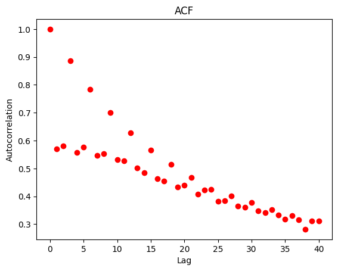

```python
plt.plot(X_acf, 'ro')
plt.xlabel('Lag')
plt.ylabel('Autocorrelation')
plt.title("ACF");
```

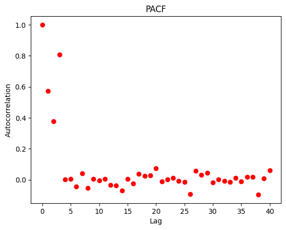

```python
plt.plot(X_pacf, 'ro')
plt.xlabel('Lag')
plt.ylabel('Autocorrelation')
plt.title("PACF");
```

### Kiểm định Thống kê

Chỉ nhìn vào các biểu đồ không đủ. Chúng ta cần sử dụng một mức độ chặt chẽ thống kê nào đó. Các hàm `acf` và `pacf` sẽ trả về các khoảng tin cậy cho tất cả các tự tương quan. Chúng ta có thể kiểm tra xem các khoảng này có chồng lấp với số không hay không. Nếu có, thì chúng ta nói rằng số không nằm trong khoảng tin cậy đã cho cho giá trị tham số thực, và không coi độ trễ là có tự tương quan có ý nghĩa.

LƯU Ý: Điều này chỉ hoạt động nếu các giả định cơ bản của việc tính toán khoảng tin cậy được thỏa mãn. Vui lòng kiểm tra các giả định này trước khi bạn nghĩ rằng kiểm định là có ý nghĩa. Các giả định sẽ khác nhau trong mỗi trường hợp, vì vậy vui lòng đọc tài liệu thống kê của bài kiểm tra của bạn và bắt đầu từ đó.

```python
# We have to set a confidence level for our intervals, we choose the standard of 95%,
# corresponding with an alpha of 0.05.
X_acf, X_acf_confs = acf(X, nlags=nlags, alpha=0.05, fft=True)
X_pacf, X_pacf_confs = pacf(X, nlags=nlags, alpha=0.05)
```

Sau khi có dữ liệu khoảng tin cậy, chúng ta sẽ viết một hàm để vẽ biểu đồ cho nó.

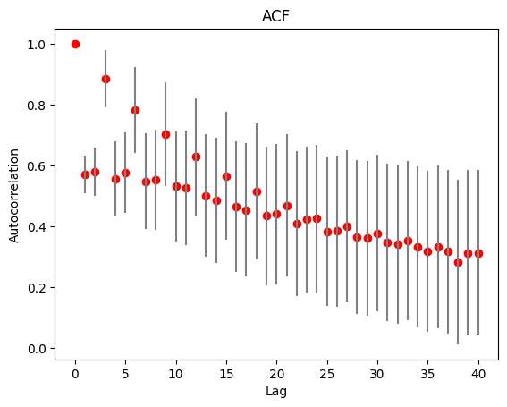

```python
def plot_acf(X_acf, X_acf_confs, title='ACF'):
    # The confidence intervals are returned by the functions as (lower, upper)
    # The plotting function needs them in the form (x-lower, upper-x)
    errorbars = np.ndarray((2, len(X_acf)))
    errorbars[0, :] = X_acf - X_acf_confs[:,0]
    errorbars[1, :] = X_acf_confs[:,1] - X_acf

    plt.plot(X_acf, 'ro')
    plt.errorbar(range(len(X_acf)), X_acf, yerr=errorbars, fmt='none', ecolor='gray', capthick=2)
    plt.xlabel('Lag')
    plt.ylabel('Autocorrelation')
    plt.title(title);
plot_acf(X_acf, X_acf_confs)
```

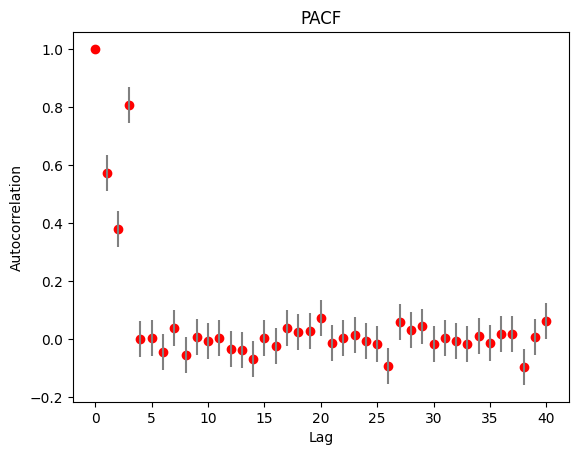

```python
plot_acf(X_pacf, X_pacf_confs, title='PACF')
```

Lưu ý rằng đối với PACF, ba độ trễ đầu tiên là những độ trễ duy nhất có vẻ khác biệt một cách đáng kể so với $0$, điều này hợp lý vì chúng ta đã trực tiếp xây dựng một mô hình AR bậc $3$. Tuy nhiên, các kết quả này có thể khác nhau cho mỗi chuỗi ngẫu nhiên được tạo ra trong bài giảng này.

Trong một chuỗi thời gian thực tế, chúng ta sử dụng các biểu đồ này để xác định bậc của mô hình. Sau đó, chúng ta sẽ cố gắng khớp một mô hình bằng cách sử dụng hàm khả năng tối đa.

## Khớp Mô Hình

Chúng ta sẽ sử dụng một trong những hàm đã được triển khai trong Python để khớp một mô hình AR. Chúng ta sẽ thử nghiệm điều này trên dữ liệu mô phỏng của mình trước.

```python
# Construct an unfitted model
model = AutoReg(X, lags=nlags)
# Fit it
model = model.fit()
```

Đối tượng `model` có nhiều thông tin hữu ích. Sử dụng ký hiệu `?` để tìm hiểu thêm. Chúng ta sẽ tập trung vào một vài thuộc tính, bắt đầu với `model.params`, là các tham số ước lượng trong mô hình, một cho mỗi độ trễ, và `model.bse`, là sai số chuẩn ước lượng cho từng tham số.

```python
print('Parameters')
print(model.params)
print('Standard Error')
print(model.bse)
```

```
Parameters
[ 0.01724111  0.04515804  0.07437131  0.85070648 -0.02068638  0.06252601
 -0.04111677  0.05337118 -0.06284995  0.02593036  0.01904109  0.05997752
 -0.03681612 -0.01146089 -0.08617622 -0.01072612 -0.06439772 -0.03987813
  0.01682804  0.04147587  0.06590082  0.01157124  0.00395936  0.10229544
 -0.05514214 -0.03724592 -0.14138476  0.06610644  0.03248547  0.05314844
 -0.01397308 -0.01714909 -0.00974412 -0.02109196  0.00723587  0.06845649
  0.02226561 -0.01984467 -0.09665417  0.00383139  0.05296155]
Standard Error
[0.03164671 0.03218896 0.03222577 0.0321575  0.04226242 0.04228592
 0.04227559 0.0423044  0.04236335 0.04244231 0.0424578  0.04246112
 0.0424676  0.0424941  0.04243313 0.04216485 0.04214158 0.04217838
 0.04205653 0.04202755 0.04215054 0.0421432  0.04214668 0.04214695
 0.04225594 0.04226372 0.04221868 0.04234144 0.04239355 0.04236347
 0.04231471 0.04231873 0.04231697 0.04224398 0.04216363 0.04214003
 0.0420803  0.04205891 0.03206092 0.03211749 0.03207347]
```

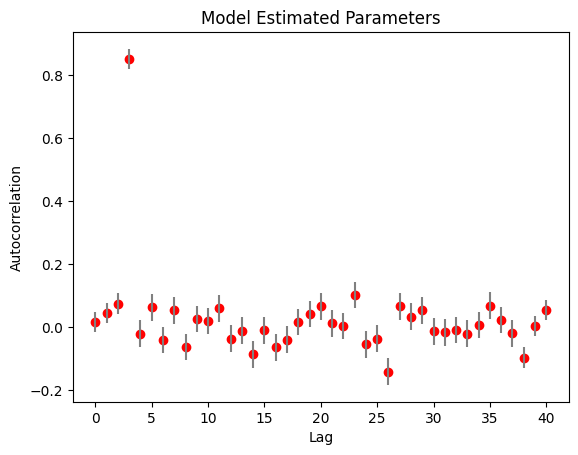

```python
# To plot this we'll need to format a confidence interval 2D array like the previous functions returned
# Here is some quick code to do that
model_confs = np.asarray((model.params - model.bse, model.params + model.bse)).T

plot_acf(model.params, model_confs, title='Model Estimated Parameters')
```

### Lựa Chọn Số Lượng Độ Trễ

#### Các Ước Tính Sẽ Đưa Ra Quá Nhiều Độ Trễ

Chúng ta có thể thấy mô hình của chúng ta ước tính khá nhiều tham số. Trong trường hợp này, chúng ta biết có quá nhiều tham số vì chúng ta đã mô phỏng dữ liệu như một quá trình AR(3). Lý do mà các mô hình AR sẽ ước tính nhiều độ trễ hơn so với thực tế là do sự phụ thuộc gián tiếp. Nếu $X_t$ phụ thuộc vào $X_{t-1}$, thì một cách gián tiếp và ở mức độ thấp hơn, nó sẽ phụ thuộc vào $X_{t-2}$. Trong sự hiện diện của nhiều hơn một độ trễ trong quá trình sinh dữ liệu, chúng ta sẽ có những cấu trúc hài hoà phức tạp trong các độ trễ. Những sự phụ thuộc gián tiếp này sẽ được một ước tính đơn giản phát hiện.

#### Bạn Muốn Số Tham Số Ít Nhất Để Có Một Mô Hình Tốt

Nói chung, hiếm khi bạn có thể thu được điều gì hữu ích từ một mô hình với nhiều tham số, xem bài giảng về Overfitting để biết lý do. Trong trường hợp này, chúng ta muốn chọn một số lượng độ trễ mà chúng ta tin là giải thích được những gì đang diễn ra, nhưng không bị overfitting và chọn một mô hình với quá nhiều độ trễ.

Quan sát ACF và PACF cho thấy chỉ có 3 độ trễ đầu tiên có thể hữu ích. Tuy nhiên, chúng tôi sẽ mở rộng số lượng độ trễ lên 10 để kiểm tra lại dữ liệu ban đầu của chúng tôi. Chúng tôi sẽ sử dụng tiêu chí thông tin, cụ thể là Tiêu chí Thông tin Akaike (AIC) và Tiêu chí Thông tin Bayes (BIC) để quyết định số lượng tham số chính xác.

Việc giải thích AIC và BIC được thực hiện như sau. Tính toán AIC và BIC cho tất cả các mô hình mà chúng ta muốn xem xét, và ghi lại AIC và BIC nhỏ nhất được ghi lại là $AIC_{min}$ và $BIC_{min}$. Đây là các mô hình mà tối thiểu hóa mất mát thông tin theo từng tiêu chí. Đối với mỗi loại IC, chúng ta có thể tính toán *khả năng tương đối* của mỗi mô hình $i$ bằng cách lấy

$$l = e^{(IC_{min} - IC_{i})/2}$$

Chúng ta có thể hiểu $l$ như là mô hình $i$ có khả năng $l$ lần để tối thiểu hóa mất mát thông tin, so với mô hình AIC tối thiểu. Có thể cần đọc lại một vài lần để hiểu điều này, vì vậy hãy cùng xem nó hoạt động như thế nào.

```python
N = 10
AIC = np.zeros((N, 1))

for i in range(N):
    model = AutoReg(X, lags=i+1)
    model = model.fit()
    AIC[i] = model.aic

AIC_min = np.min(AIC)
model_min = np.argmin(AIC)

print('Relative Likelihoods')
print(np.exp((AIC_min-AIC) / 2))
print('Number of parameters in minimum AIC model %s' % (model_min+1))
```

```
Relative Likelihoods
[[3.42392207e-267]
 [2.11594960e-233]
 [7.54235317e-005]
 [1.32513917e-004]
 [1.28343856e-004]
 [4.93854288e-004]
 [1.85277495e-003]
 [3.80449459e-001]
 [3.61523370e-001]
 [1.00000000e+000]]
Number of parameters in minimum AIC model 10
```

```python
N = 10
BIC = np.zeros((N, 1))

for i in range(N):
    model = AutoReg(X, lags=i+1)
    model = model.fit()
    BIC[i] = model.bic

BIC_min = np.min(BIC)
model_min = np.argmin(BIC)

print('Relative Likelihoods')
print(np.exp((BIC_min-BIC) / 2))
print('Number of parameters in minimum BIC model %s' % (model_min+1))
```

```
Relative Likelihoods
[[6.11300002e-261]
 [3.25386364e-228]
 [1.00000000e+000]
 [1.51631694e-001]
 [1.26874941e-002]
 [4.22191456e-003]
 [1.37113860e-003]
 [2.43973483e-002]
 [2.01098375e-003]
 [4.82990886e-004]]
Number of parameters in minimum BIC model 3
```

### Đánh giá phần dư

Một bước cuối cùng mà chúng ta có thể thực hiện trước khi tiến hành kiểm tra ngoài mẫu cho mô hình này là đánh giá hành vi của phần dư. AIC và BIC đã làm điều này đến một mức độ nào đó, hiệu quả đo lường lượng thông tin còn lại (trong phần dư) sau khi mô hình đã đưa ra dự đoán. Để biết thêm thông tin về phân tích phần dư, hãy xem bài giảng Vi phạm các mô hình hồi quy. Ở đây, chúng ta sẽ chỉ kiểm tra tính chuẩn của các phần dư.

```python
model = AutoReg(X, lags=3)
model = model.fit()

from statsmodels.stats.stattools import jarque_bera

score, pvalue, _, _ = jarque_bera(model.resid)

if pvalue < 0.10:
    print('We have reason to suspect the residuals are not normally distributed.')
else:
    print('The residuals seem normally distributed.')
```

```
The residuals seem normally distributed.
```

Các phần dư có vẻ phân phối chuẩn. Còn nhiều bước xác thực mô hình khác có thể thực hiện, nhưng đây là những bước chính cho mô hình AR. Các bước tiếp theo sẽ là kiểm tra mô hình ngoài mẫu và sau đó sử dụng nó để đưa ra dự đoán trên dữ liệu của bạn.

## Tham khảo

- "Quantitative Investment Analysis", by DeFusco, McLeavey, Pinto, and Runkle
- "Analysis of Financial Time Series", by Ruey Tsay

*Lưu ý: Tài liệu này mang tính chất chia sẻ kiến thức khoa học dữ liệu. Các mã chứng khoán xuất hiện trong tài liệu chỉ mang tính chất minh hoạ, không khuyến nghị đầu tư. Chúng tôi không chịu trách nhiệm trước mọi rủi ro nào do sử dụng tài liệu này.*